# Chapter 14.4 - Dyad Models in Nicaragua

Another example of covariance and using a multi-normal distribution to model this.

Data is 25 families in rural Nicaragua giving gifts to each other.

Count data with no obvious max so going to use poisson with usual log link.

$gifts_{A -> B} \sim Poisson(\lambda_{AB})$

Model lambda as being a linear model from generalized giving rate alpha, a random effect for this specific household A, ditto for the receiving household B, both regardless of dyad. Additionally have a dyad-specific rate that A gives to B.

$log\lambda_{AB} = \alpha + g_A + r_B + d_{AB}$

And vice-versa

$gifts_{B -> A} \sim Poisson(\lambda_{BA})$

$log\lambda_{BA} = \alpha + g_B + r_A + d_{BA}$

The reason why we’re talking about this with regards to covariance is the fact that we want the giving and receiving rates of each household to co-vary. Do households that give more also receive more? Or do those that give more receive less? Or is there no correlation?
$$\begin{pmatrix}
g_i \\ r_i
\end{pmatrix}
\sim MVNormal
\left(
\begin{pmatrix}
0 \\ 0
\end{pmatrix},
\begin{pmatrix}
\sigma_g^2 & \sigma_g \sigma_r \rho_{gr} \\
\sigma_g \sigma_r \rho_{gr} & \sigma_r^2
\end{pmatrix}
\right)$$
Hence the multi-normal prior we will include to allow this correlation.

If $\rho_{gr}$ is positive, households that give more also tend to receive more. If negative, vice-versa. If zero, no relationship. This is in general.

Similarly, interested in dyad effects co-varying.
$$\begin{pmatrix}
d_{ij} \\ d_{ji}
\end{pmatrix}
\sim MVNormal
\left(
\begin{pmatrix}
0 \\ 0
\end{pmatrix},
\begin{pmatrix}
\sigma_d^2 & \sigma_d^2 \rho_{d} \\
\sigma_d^2\rho_{d} & \sigma_d^2
\end{pmatrix}
\right)$$
After considering households’ general giving and receiving rates, are there relationships between specific pairs of households where the two households give a lot to each other, or one gives and the other receives?

Only one $\sigma_d$ here cos the ordering shouldn’t matter.

Creating the model, need to be careful. Here gr[hidA, 1] means the *giving* rate of household A, and gr[hidA, 2] means the *receiving* rate.

Also doing the non-centred thing here, with the correlation matrix specified as a generated quantity in the last block.

```r
library(rethinking)
data("KosterLeckie")
```

```r
kl_data <- list(
  N = nrow(kl_dyads),
  N_households = max(kl_dyads$hidB),
  did = kl_dyads$did,
  hidA = kl_dyads$hidA,
  hidB = kl_dyads$hidB,
  giftsAB = kl_dyads$giftsAB,
  giftsBA = kl_dyads$giftsBA
)
```

```r
m14.7 <- ulam(
  alist(
    giftsAB ~ poisson(lambdaAB),
    giftsBA ~ poisson(lambdaBA),
    log(lambdaAB) <- a + gr[hidA, 1] + gr[hidB, 2] + d[did, 1],
    log(lambdaBA) <- a + gr[hidB, 1] + gr[hidA, 2] + d[did, 2],
    a ~ normal(0, 1),

    vector[2]:gr[N_households] ~ multi_normal(0, Rho_gr, sigma_gr),
    Rho_gr ~ lkj_corr(4),
    sigma_gr ~ exponential(1),

    transpars> matrix[N,2]:d <-
      compose_noncentered(rep_vector(sigma_d, 2), L_Rho_d, z),
    matrix[2,N]: z ~ normal(0, 1),

    cholesky_factor_corr[2]:L_Rho_d ~ lkj_corr_cholesky(8),
    sigma_d ~ exponential(1),

    gq> matrix[2, 2]:Rho_d <<- Chol_to_Corr(L_Rho_d)

  ), data=kl_data, chains=4, iter=2000
)
```

```r
precis(m14.7, depth=3, pars=c("Rho_gr", "sigma_gr"))
```

|  | mean | sd | 5.5% | 94.5% | n_eff | Rhat4 |
| --- | --- | --- | --- | --- | --- | --- |
| Rho_gr[1,1] | 1.00 | 0.00 | 1.00 | 1.00 | NaN | NaN |
| Rho_gr[1,2] | -0.40 | 0.20 | -0.71 | -0.06 | 1247 | 1 |
| Rho_gr[2,1] | -0.40 | 0.20 | -0.71 | -0.06 | 1247 | 1 |
| Rho_gr[2,2] | 1.00 | 0.00 | 1.00 | 1.00 | 4081 | 1 |
| sigma_gr[1] | 0.83 | 0.14 | 0.65 | 1.06 | 2115 | 1 |
| sigma_gr[2] | 0.42 | 0.09 | 0.29 | 0.58 | 1275 | 1 |

Results! See that $\rho_{gr}$ is negative, with 89% of its mass below zero. Households that give do less receiving and vice-versa. There is more variation in giving than in receiving.

```r
post <- extract.samples(m14.7)
g <- sapply(1:25, function(i) post$a + post$gr[ , i, 1])
r <- sapply(1:25, function(i) post$a + post$gr[ , i, 2])
Eg_mu <- apply(exp(g), 2, mean)
Er_mu <- apply(exp(r), 2, mean)
plot( NULL, xlim=c(0, 8.6), ylim=c(0, 8.6), xlab="generalized giving",
      ylab="generalized receiving", lwd=1.5)
abline(a=0, b=1, lty=2)
```

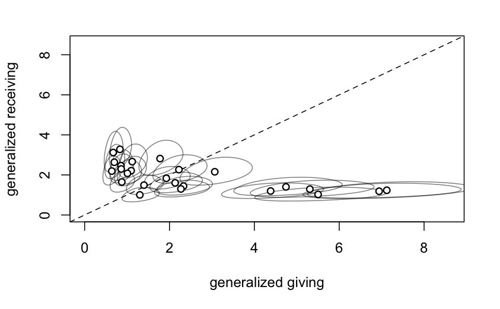

```r
library(ellipse)
for ( i in 1:25 ) {
  Sigma <- cov(cbind( g[,i], r[,i]))
  Mu <- c(mean(g[,i]), mean(r[,i]))
  el <- ellipse(Sigma, centre=Mu, level=0.5)
  lines(exp(el), col=col.alpha("black", 0.5))
}
points(Eg_mu, Er_mu, pch=21, bg="white", lwd=1.5)
```

Plot of each household’s generalized giving and receiving, after taking into account dyad effects. Can see the uncertainty in the posterior estimates for each household, and also the rough negative correlation.

```r
precis(m14.7, depth=3, pars=c("Rho_d", "sigma_d"))
```

|  | mean | sd | 5.5% | 94.5% | n_eff | Rhat4 |
| --- | --- | --- | --- | --- | --- | --- |
| Rho_d[1,1] | 1.00 | 0.00 | 1.00 | 1.00 | NaN | NaN |
| Rho_d[1,2] | 0.88 | 0.03 | 0.83 | 0.93 | 1195 | 1 |
| Rho_d[2,1] | 0.88 | 0.03 | 0.83 | 0.93 | 1195 | 1 |
| Rho_d[2,2] | 1.00 | 0.00 | 1.00 | 1.00 | NaN | NaN |
| sigma_d | 1.10 | 0.06 | 1.01 | 1.20 | 1157 | 1 |

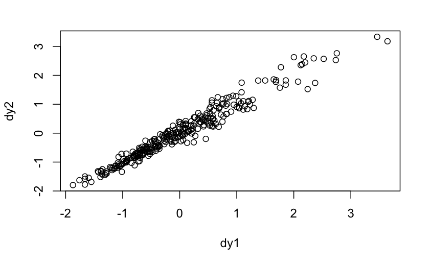

```r
dy1 <- apply(post$d[,,1], 2, mean)
dy2 <- apply(post$d[,,2], 2, mean)
plot(dy1, dy2)
```

Dyad effect results. Very strong dyad effects! High value of $\sigma_d$ and it’s very certain about it.